# ACA project

Sadie Lyons

2026-04-30

AI disclosure statement: While I did not use AI to write code for this project, I used it to help troubleshoot and format my figures.

- For graphs and regression tables, I would use it to fix overlapping text or clean up the appearance.
- I also used it at the end of my project by having it format my already-written code so that it was easier for graders to read.
- AI taught me to use “skip” when reading a csv so that my categories of variables were assigned properly.
- used it to help me put minor tick marks in my line plot

# **Project Introduction**

The Affordable Care Act was put into action for the first time on January 1st, 2014. It promised to expand government-funded healthcare, making it cheaper for middle and low income families to afford their medical costs. This project explores the efficacy of that bill in terms of out-of-pocket healthcare spending. However, not all states adopted the expansion right away. Some states still have not expanded their medicaid as of 2026, and while 22 states joined in 2014, several others expanded later. This project aims to map the efficacy of the bill over time by using a difference-in-differences deign by comparing the benefits for states who were early enrollers (2014) vs late (2015 - 2024).

## My Hypothesis:

**1. States that expanded medicaid under the Affordable Care Act will have lower proportions of residents experiencing a high financial burden due to medical cost.**

**2. The effects on these metrics will be greater for States that expanded in 2014 (“Early”) than those that expanded from 2015 to 2023 (“Late”).**

I think this will prove true because the lack of insurance coverage can often be attributed to financial inaccessibility and restraints on eligibility. The affordable care act attempted to lower both of these hurdles for the American public.

Many low-income adults earn too much to qualify for traditional Medicaid, but too little to afford private insurance coverage. This creates a coverage gap for middle-income and some low-income households.

Ideally, when prices of healthcare decrease and eligibility is expanded through federal programs, healthcare coverage nationwide should increase, and cost/burden should decrease.

Examining these questions is important because the financial burden of healthcare shapes life outcomes, keeps people from regularly attending doctors’ visits, and shapes political opinions.

## Explanatory Variables:

As stated earlier, this project uses a difference-in-differences model. Basically, I will be analyzing coverage levels and burden rates across states and across years.

**Variable 1:** State expansion. Did this state adopt the Affordable Care Act’s adjustments? This will be a simple “yes” or “no” in terms of measurements, and can be accessed through public data and state legislature. (output 0 or 1)

**Variable 2:** Time of expansion. Through state legislature, I was able to find the medicaid expansion date (or lack thereof) for all 50 states. Since one main goal of this project is to map the ACA’s efficacy over time, states will be split into cohorts depending on when they elected to expand medicaid. Early expanders occur in 2014. Because states joined sporadically after that, late expanders will be 2015 to 2023.

## Outcome Variable:

**Proportion of people with a high medical burden.** According to SHADAC and the University of Minnesota, this is qualified as “Share of individuals who are in families where out-of-pocket spending on health care, including premiums, accounted for more than 10 percent of annual income for the civilian non-institutionalized population.”

## What would prove my hypothesis true?

After expansion begins (2014), burden rates decline more sharply in expansion states than in non-expansion states.

The correlation on the expansion variable is:

- Negative (meaning states who adopted the act had decreased burden over time)
- Statistically significant
- Additionally, (for hyp 2,) these correlations are stronger for Early expanders.

## What would disprove my hypothesis?

- Expansion and non-expansion states had no statistically significant difference in the proportion of people with a high medical burden.
- Early vs late expanders showed no significant difference in the above metric.

# High Medical Burden Rate by Cohort (Line Plots) – Data section/Variable visualization

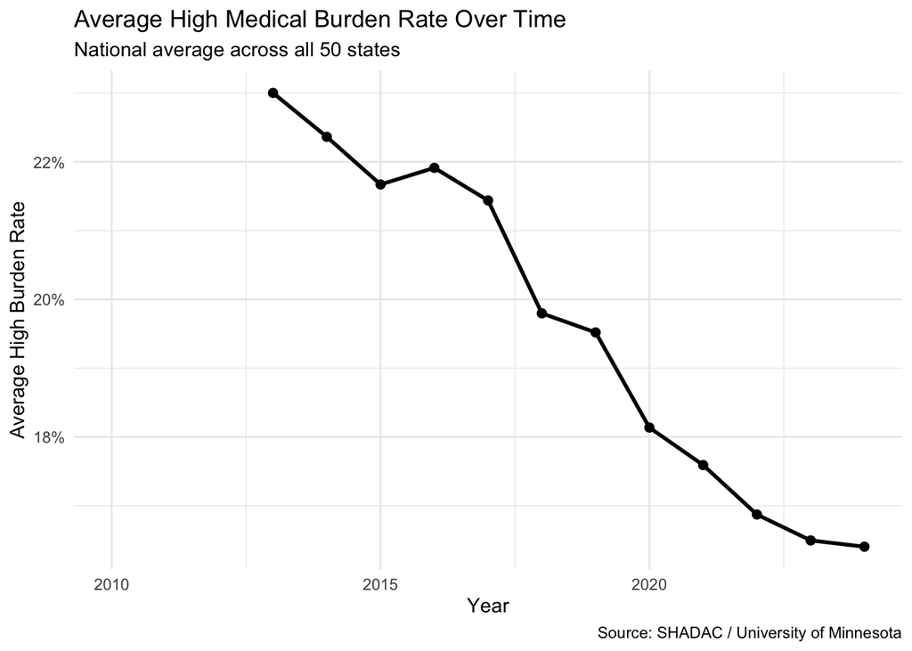

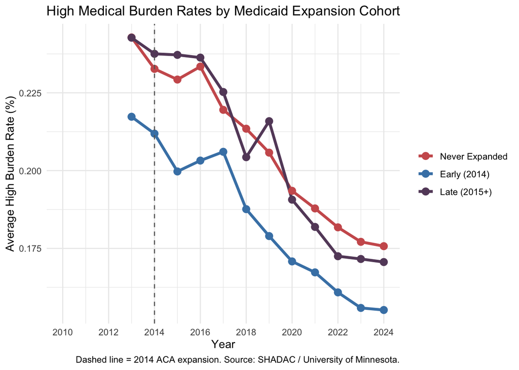

# ** RESULTS** – BOX PLOT WITH SIGNIFICANCE INDICATORS

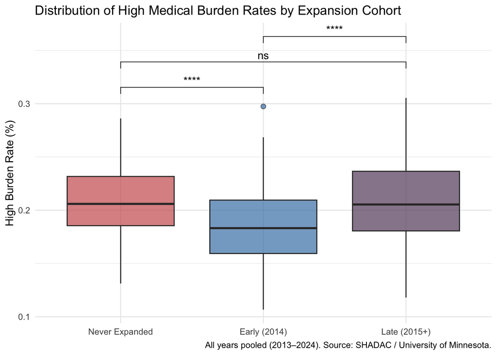

**Interpretation**

From this boxplot, we see the distribution of high medical burden rates for each of our cohorts. The Early cohort has the lowest mean, with the “Never Expanded” and “Late” cohorts having high means. The range of values in each cohort is roughly the same. The stars branching between the “Never” and “Early” boxes show significance, as do the Early vs Late. “ns” here stands for not significant.

# **REGRESSION MODEL**

| Term | Estimate | Std. Error | P-value |
| --- | --- | --- | --- |
| Baseline Burden Rate (Never Expanded, Pre-2014) | 0.243 | 0.010 | 0.000 |
| Early Expansion States (2014) | -0.025 | 0.012 | 0.037 |
| Late Expansion States (2015+) | 0.000 | 0.014 | 0.995 |
| Post-2014 Period | -0.038 | 0.011 | 0.000 |
| Early × Post (DiD Effect) | 0.003 | 0.013 | 0.843 |
| Late × Post (DiD Effect) | 0.000 | 0.014 | 0.972 |

**Interpretation:**

- The intercept represents the baseline average high medical burden rate in Never Expanded states prior to 2014.
- The Post-2014 coefficient captures the average change in burden rates after 2014 across all states, reflecting nationwide time trends unrelated to Medicaid expansion.
- The points of interest are the difference-in-differences interaction terms. The Early (2014) × Post coefficient measures how much more (or less) high medical burden changed in early expansion states after 2014 relative to never-expanding states. The Late (2015+) × Post coefficient captures the same comparison for states that expanded after 2014.

We cannot reject the null hypothesis for the difference-in-differences effects (Early × Post and Late × Post).This is because both interaction terms—the coefficients that capture the causal effect of Medicaid expansion in the DiD framework—have very large p-values (0.8433 and 0.9721), which are far above the alpha of 0.05. Therefore, the differences could easily be due to random chance.

However, correlation does not equal causation. You can’t interpret this causally because states chose whether to expand Medicaid — there was no random assignment. States that expanded likely could also have political differences, healthcare policy bills in addition to ACA, or demographics that affected BOTH whether the state expanded AND whether uninsured rates dropped.

# Conclusion:

Overall, the results offer only partial support for my hypotheses. The boxplot and line plot suggest that Early (2014) expansion states had lower high burden rates than Never Expanded states (a statistically significant difference), which is consistent with Hypothesis 1. However, the difference-in-differences regression did not find statistically significant interactions between Early and Late cohorts, so Hypothesis 2 was not supported. Several limitations threaten inference here: states self-selected into expansion, meaning political climate, demographics, and pre-existing healthcare infrastructure likely confound the results. Missing data in certain state-year combinations further weakens the analysis. With more time and resources, I would measure multiple metrics like uninsured rates, the number of preventable hospital/ER visits, and more.

```r
knitr::opts_chunk$set(echo = FALSE, message = FALSE, warning = FALSE)

options(readr.show_col_types = FALSE)

library(tidyverse)
library(janitor)
library(modelsummary)
library(ggplot2)
library(readr)
library(dplyr)
library(ggpubr)
library(infer)
library(broom)
library(kableExtra)
expansion_data <- read_csv("Datasets/medicaid_expansion_tracker.csv", show_col_types = FALSE)
perc_uninsured  <- read_csv("Datasets/2008to2024_coverage.csv", show_col_types = FALSE)
burden2013.17   <- read_csv("Datasets/burden2013-2017.csv", skip = 6, show_col_types = FALSE)
burden2017.24   <- read_csv("Datasets/resave_burden2024.csv", skip = 7, show_col_types = FALSE)
# For 2017–2024
burden2017.24 <- burden2017.24[, !(names(burden2017.24) %in% c("Fips", "MOE", "Data Type"))]
names(burden2017.24) <- c("State", "Year", "High Burden Prop")
burden2017.24$State            <- as.character(burden2017.24$State)
burden2017.24$Year             <- as.numeric(burden2017.24$Year)
burden2017.24$`High Burden Prop` <- as.numeric(burden2017.24$`High Burden Prop`)

# For 2013–2017
burden2013.17 <- burden2013.17[, !(names(burden2013.17) %in% c("Fips", "MOE", "Data Type"))]
names(burden2013.17) <- c("State", "Year", "High Burden Prop")
burden2013.17$State            <- as.character(burden2013.17$State)
burden2013.17$Year             <- as.numeric(burden2013.17$Year)
burden2013.17$`High Burden Prop` <- as.numeric(burden2013.17$`High Burden Prop`)
burden_all <- rbind(burden2013.17, burden2017.24)
burden_all <- burden_all[!(duplicated(burden_all[, c("State", "Year")])), ]
burden_all <- burden_all[order(burden_all$State, burden_all$Year), ]
burden_all$State <- trimws(burden_all$State)
burden_all <- burden_all |>
  mutate(State = str_to_upper(str_trim(State)))

burden_clean <- burden_all |>
  rename(
    state            = State,
    year             = Year,
    high_burden_prop = `High Burden Prop`
  )
expansion_clean <- expansion_data |>
  clean_names() |>
  mutate(
    state          = str_to_upper(str_trim(state)),
    expansion_year = as.integer(str_extract(expansion_date, "\\d{4}"))
  ) |>
  mutate(
    cohort = case_when(
      expansion_year == 2014 ~ "Early (2014)",
      expansion_year > 2014  ~ "Late (2015+)",
      is.na(expansion_year)  ~ "Never Expanded"
    )
  ) |>
  select(state, expansion_year, cohort)

coverage_clean <- perc_uninsured |>
  clean_names() |>
  mutate(
    state         = str_to_upper(str_trim(state)),
    year          = as.integer(year),
    uninsured_rate = as.numeric(uninsured),
    medicaid_rate  = as.numeric(medicaid)
  ) |>
  filter(year >= 2010, year <= 2024, state != "UNITED STATES") |>
  select(state, year, uninsured_rate, medicaid_rate)

master_data <- coverage_clean |>
  left_join(burden_clean, by = c("state", "year")) |>
  left_join(expansion_clean, by = "state") |>
  mutate(
    cohort = factor(cohort),
    three_yr_window = ifelse(
      !is.na(expansion_year) &
      year >= expansion_year &
      year <= expansion_year + 3,
      1, 0
    )
  )

master_data <- master_data |>
  mutate(
    cohort = str_trim(cohort),
    cohort = factor(cohort),
    cohort = relevel(cohort, ref = "Never Expanded"),
    post   = ifelse(year >= 2014, 1, 0)
  )
master_data |>
  group_by(year) |>
  summarize(avg_burden = mean(high_burden_prop, na.rm = TRUE)) |>
  ggplot(aes(x = year, y = avg_burden)) +
  geom_line(color = "black", linewidth = 1) +
  geom_point(color = "black", size = 2) +
  scale_y_continuous(labels = scales::percent_format(accuracy = 1)) +
  labs(
    title = "Average High Medical Burden Rate Over Time",
    subtitle = "National average across all 50 states",
    x = "Year",
    y = "Average High Burden Rate",
    caption = "Source: SHADAC / University of Minnesota"
  ) +
  theme_minimal()
DiD_burden <- master_data |>
  group_by(year, cohort) |>
  summarize(mean_burden = mean(high_burden_prop, na.rm = TRUE), .groups = "drop")

ggplot(DiD_burden, aes(x = year, y = mean_burden, color = cohort)) +
  geom_line(linewidth = 1.3) +
  geom_point(size = 3) +
  geom_vline(xintercept = 2014, linetype = "dashed", color = "grey40") +
  scale_color_manual(values = c(
    "Early (2014)"   = "steelblue",
    "Late (2015+)"   = "#644969",
    "Never Expanded" = "indianred"
  )) +
  labs(
    title   = "High Medical Burden Rates by Medicaid Expansion Cohort",
    x       = "Year",
    y       = "Average High Burden Rate (%)",
    color   = NULL,
    caption = "Dashed line = 2014 ACA expansion. Source: SHADAC / University of Minnesota."
  ) +
  theme_minimal() +
  scale_x_continuous(
    breaks       = seq(2010, 2024, by = 2),
    minor_breaks = 2010:2024
  )
ggplot(master_data, aes(x = cohort, y = high_burden_prop, fill = cohort)) +
  geom_boxplot(alpha = 0.7, outlier.shape = 21, outlier.size = 2) +
  scale_fill_manual(values = c(
    "Early (2014)"   = "steelblue",
    "Late (2015+)"   = "#644969",
    "Never Expanded" = "indianred"
  )) +
  stat_compare_means(
    comparisons = list(
      c("Early (2014)", "Never Expanded"),
      c("Late (2015+)", "Never Expanded"),
      c("Early (2014)", "Late (2015+)")
    ),
    method = "wilcox.test",
    label  = "p.signif"
  ) +
  labs(
    title   = "Distribution of High Medical Burden Rates by Expansion Cohort",
    x       = NULL,
    y       = "High Burden Rate (%)",
    fill    = NULL,
    caption = "All years pooled (2013–2024). Source: SHADAC / University of Minnesota."
  ) +
  theme_minimal() +
  theme(legend.position = "none")
model_burden <- lm(high_burden_prop ~ cohort * post, data = master_data)

tidy(model_burden) |>
  mutate(
    term = recode(term,
      "(Intercept)"                  = "Baseline Burden Rate (Never Expanded, Pre-2014)",
      "cohortEarly (2014)"           = "Early Expansion States (2014)",
      "cohortLate (2015+)"           = "Late Expansion States (2015+)",
      "post"                         = "Post-2014 Period",
      "cohortEarly (2014):post"      = "Early × Post (DiD Effect)",
      "cohortLate (2015+):post"      = "Late × Post (DiD Effect)"
    ),
    p.value = round(p.value, 4)
  ) |>
  select(term, estimate, std.error, p.value) |>
 kable(digits = 3, col.names = c("Term", "Estimate", "Std. Error", "P-value"))
```